# Laboratorio 7

Federico Daverio

```r
rm(list=ls())
setwd("C:/DAVE2/CIDE/Doc/Econometria II/Lab_7")
options(scipen=999)

library(tidyverse)
library(janitor)
library(modelsummary)
library(nnet)
library(mlogit)
library(sandwich)
```

```r
require(ggplot2)
require(sandwich)
require(msm)
```

# **Grafo: así actúa una VI**

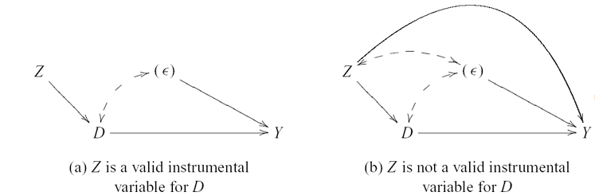

# El método de Variables Intrumentales

- **Objetivo**:obtener estimadores consistentes de los parámetros del modelo en presencia de variables explicativas endógenas

**Recuerda**:

Comandos claves en R(funciones):

- $\texttt{ivreg}$: correo regresiones de VI (2SLS) (requiere paquete $\texttt{AER}$)

Puntos/conceptos claves:

- $\texttt{ivreg}$ trabaja como $\texttt{lm}$. La sintaxis para $\texttt{ivreg}$ es como sigue: $\texttt{ivreg(Y ~ X + W | W + Z, ... )}$, donde $X$ es o son variable(s) endogena, $Z$ es un instrumento(s), y $W$ son controles exógenos(no instrumentos). Pruebas de diagnóstico se obtienen vía $\texttt{summary(modelo, diagnostics=TRUE)}$.

# Ejemplo

Los datos provienen de la una Encuesta Nacional Longitudinal. Estos datos comenzaron en 1966 con 5.525 hombres de entre 14 y 24 años y continuaron su seguimiento hasta 1981. Estos datos provienen de 1966, la encuesta de referencia, y hay una serie de preguntas relacionadas con los mercados laborales locales. Uno de ellos es si el encuestado vive en el mismo condado que una universidad de 4 años (y 2 años).

Card era itneresado a estimar la siguiente expresi+on:

$$Y_i=\alpha+\delta S_i + \gamma X_i+\varepsilon_i$$

Donde $Y$ es el logaritmo de los salario y $S$ los años de escolaridad ($X$ son unos regresores exogenos).

Pero hay abilidad en el error que puede ser correlacionadoa con C

```r
library(AER)
library(haven)
library(tidyverse)

read_data <- function(df)
{
  full_path <- paste("https://raw.github.com/scunning1975/mixtape/master/",
                     df, sep = "")
  df <- read_dta(full_path)
  return(df)
}

card <- read_data("card.dta")

#Define variable
#(Y1 = Dependent Variable, Y2 = endogenous variable, X1 = exogenous variable, X2 = Instrument)

attach(card)

Y1 <- lwage
Y2 <- educ
X1 <- cbind(exper, black, south, married, smsa)
X2 <- nearc4

#OLS
ols_reg <- lm(Y1 ~ Y2 + X1)
summary(ols_reg)
```

```
##
## Call:
## lm(formula = Y1 ~ Y2 + X1)
##
## Residuals:
##      Min       1Q   Median       3Q      Max
## -1.59924 -0.23035  0.01812  0.23046  1.36797
##
## Coefficients:
##              Estimate Std. Error t value            Pr(>|t|)
## (Intercept)  5.063317   0.063740  79.437 <0.0000000000000002 ***
## Y2           0.071173   0.003482  20.438 <0.0000000000000002 ***
## X1exper      0.034152   0.002214  15.422 <0.0000000000000002 ***
## X1black     -0.166027   0.017614  -9.426 <0.0000000000000002 ***
## X1south     -0.131552   0.014969  -8.788 <0.0000000000000002 ***
## X1married   -0.035871   0.003401 -10.547 <0.0000000000000002 ***
## X1smsa       0.175787   0.015458  11.372 <0.0000000000000002 ***
## ---
## Signif. codes:  0 '***' 0.001 '**' 0.01 '*' 0.05 '.' 0.1 ' ' 1
##
## Residual standard error: 0.3702 on 2996 degrees of freedom
##   (7 observations deleted due to missingness)
## Multiple R-squared:  0.305,  Adjusted R-squared:  0.3036
## F-statistic: 219.2 on 6 and 2996 DF,  p-value: < 0.00000000000000022
```

```r
#2SLS
iv_reg = ivreg(Y1 ~ Y2 + X1 | X1 + X2)
summary(iv_reg)
```

```
##
## Call:
## ivreg(formula = Y1 ~ Y2 + X1 | X1 + X2)
##
## Residuals:
##      Min       1Q   Median       3Q      Max
## -1.81301 -0.23805  0.01766  0.24727  1.32278
##
## Coefficients:
##              Estimate Std. Error t value       Pr(>|t|)
## (Intercept)  4.162476   0.849590   4.899 0.000001012403 ***
## Y2           0.124164   0.049956   2.485        0.01299 *
## X1exper      0.055588   0.020286   2.740        0.00618 **
## X1black     -0.115686   0.050741  -2.280        0.02268 *
## X1south     -0.113165   0.023244  -4.869 0.000001182264 ***
## X1married   -0.031975   0.005087  -6.286 0.000000000373 ***
## X1smsa       0.147707   0.030895   4.781 0.000001829342 ***
## ---
## Signif. codes:  0 '***' 0.001 '**' 0.01 '*' 0.05 '.' 0.1 ' ' 1
##
## Residual standard error: 0.3843 on 2996 degrees of freedom
## Multiple R-Squared: 0.2513,  Adjusted R-squared: 0.2498
## Wald test: 139.8 on 6 and 2996 DF,  p-value: < 0.00000000000000022
```

```r
summary(lm(Y2~X1+X2))
```

```
##
## Call:
## lm(formula = Y2 ~ X1 + X2)
##
## Residuals:
##     Min      1Q  Median      3Q     Max
## -7.6308 -1.4454 -0.0526  1.2986  6.3449
##
## Coefficients:
##             Estimate Std. Error t value             Pr(>|t|)
## (Intercept) 16.83070    0.13075 128.727 < 0.0000000000000002 ***
## X1exper     -0.40443    0.00894 -45.238 < 0.0000000000000002 ***
## X1black     -0.94753    0.09053 -10.467 < 0.0000000000000002 ***
## X1south     -0.29735    0.07906  -3.761             0.000173 ***
## X1married   -0.07269    0.01775  -4.096          0.000043142 ***
## X1smsa       0.42090    0.08487   4.959          0.000000747 ***
## X2           0.32728    0.08242   3.971          0.000073339 ***
## ---
## Signif. codes:  0 '***' 0.001 '**' 0.01 '*' 0.05 '.' 0.1 ' ' 1
##
## Residual standard error: 1.937 on 2996 degrees of freedom
##   (7 observations deleted due to missingness)
## Multiple R-squared:  0.4774, Adjusted R-squared:  0.4764
## F-statistic: 456.1 on 6 and 2996 DF,  p-value: < 0.00000000000000022
```

## Ejemplo de los jueces

```r
library(tidyverse)
library(haven)
library(estimatr)
library(lfe)
library(SteinIV)
read_data <- function(df)
{
  full_path <- paste("https://raw.github.com/scunning1975/mixtape/master/",
                     df, sep = "")
  df <- read_dta(full_path)
  return(df)
}

judge <- read_data("judge_fe.dta")

#grouped variable names from the data set
judge_pre <- judge %>%
  select(starts_with("judge_")) %>%
  colnames() %>%
  subset(., . != "judge_pre_8") %>% # remove one for colinearity
  paste(., collapse = " + ")

demo <- judge %>%
  select(black, age, male, white) %>%
  colnames() %>%
  paste(., collapse = " + ")

off <- judge %>%
  select(fel, mis, sum, F1, F2, F3, M1, M2, M3, M) %>%
  colnames() %>%
  paste(., collapse = " + ")

prior <- judge %>%
  select(priorCases, priorWI5, prior_felChar,
         prior_guilt, onePrior, threePriors) %>%
  colnames() %>%
  paste(., collapse = " + ")

control2 <- judge %>%
  mutate(bailDate = as.numeric(bailDate)) %>%
  select(day, day2, bailDate,
         t1, t2, t3, t4, t5) %>% # all but one time period for colinearity
  colnames() %>%
  paste(., collapse = " + ")

#formulas used in the OLS
min_formula <- as.formula(paste("guilt ~ jail3 + ", control2))
max_formula <- as.formula(paste("guilt ~ jail3 + possess + robbery + DUI1st + drugSell + aggAss",
                                demo, prior, off, control2, sep = " + "))

#max variables and min variables
min_ols <- lm_robust(min_formula, data = judge)
max_ols <- lm_robust(max_formula, data = judge)

#--- Instrumental Variables Estimations
#-- 2sls main results
#- Min and Max Control formulas
min_formula <- as.formula(paste("guilt ~ ", control2, " | 0 | (jail3 ~ 0 +", judge_pre, ")"))
max_formula <- as.formula(paste("guilt ~", demo, "+ possess +", prior, "+ robbery +",
                                off, "+ DUI1st +", control2, "+ drugSell + aggAss | 0 | (jail3 ~ 0 +", judge_pre, ")"))
#2sls for min and max
min_iv <- felm(min_formula, data = judge)
summary(min_iv)
```

```
##
## Call:
##    felm(formula = min_formula, data = judge)
##
## Residuals:
##     Min      1Q  Median      3Q     Max
## -0.6563 -0.4798 -0.3752  0.5159  0.6248
##
## Coefficients:
##                    Estimate     Std. Error t value         Pr(>|t|)
## (Intercept)  -0.41621901427  0.12925456042  -3.220          0.00128 **
## day          -0.00006573049  0.00002539727  -2.588          0.00965 **
## day2          0.00000008138  0.00000006072   1.340          0.18021
## bailDate      0.00005867932  0.00000849754   6.905 0.00000000000501 ***
## t1            0.00504910528  0.01600356539   0.315          0.75238
## t2           -0.01512167760  0.01256807593  -1.203          0.22891
## t3            0.00693751049  0.01099805912   0.631          0.52818
## t4            0.01748923008  0.00723265644   2.418          0.01560 *
## t5            0.00048306154  0.00506691013   0.095          0.92405
## `jail3(fit)`  0.15102193139  0.06517252622   2.317          0.02049 *
## ---
## Signif. codes:  0 '***' 0.001 '**' 0.01 '*' 0.05 '.' 0.1 ' ' 1
##
## Residual standard error: 0.5036 on 331961 degrees of freedom
## Multiple R-squared(full model): -0.01483   Adjusted R-squared: -0.01486
## Multiple R-squared(proj model): -0.01483   Adjusted R-squared: -0.01486
## F-statistic(full model):  271 on 9 and 331961 DF, p-value: < 0.00000000000000022
## F-statistic(proj model):   271 on 9 and 331961 DF, p-value: < 0.00000000000000022
## F-statistic(endog. vars): 5.37 on 1 and 331961 DF, p-value: 0.02049
```

```r
max_iv <- felm(max_formula, data = judge)
summary(max_iv)
```

```
##
## Call:
##    felm(formula = max_formula, data = judge)
##
## Residuals:
##     Min      1Q  Median      3Q     Max
## -1.4475 -0.4315 -0.1008  0.4401  1.0786
##
## Coefficients:
##                     Estimate     Std. Error t value             Pr(>|t|)
## (Intercept)   -0.51450590001  0.12278285184  -4.190    0.000027856863305 ***
## black          0.05904119227  0.00538958398  10.955 < 0.0000000000000002 ***
## age            0.00151199452  0.00011149721  13.561 < 0.0000000000000002 ***
## male          -0.05157883981  0.00695302170  -7.418    0.000000000000119 ***
## white          0.10158565078  0.00362867489  27.995 < 0.0000000000000002 ***
## possess       -0.05676290142  0.00380825255 -14.905 < 0.0000000000000002 ***
## priorCases    -0.00576958909  0.00024645462 -23.410 < 0.0000000000000002 ***
## priorWI5       0.02671006781  0.00532909997   5.012    0.000000538623028 ***
## prior_felChar -0.00734279899  0.00076303854  -9.623 < 0.0000000000000002 ***
## prior_guilt    0.02368212064  0.00103371259  22.910 < 0.0000000000000002 ***
## onePrior       0.04771462151  0.00348531760  13.690 < 0.0000000000000002 ***
## threePriors   -0.00037864493  0.00432975707  -0.087              0.93031
## robbery       -0.09734393646  0.00788508542 -12.345 < 0.0000000000000002 ***
## fel           -0.02575521316  0.00974496576  -2.643              0.00822 **
## mis            0.13383347366  0.01000540037  13.376 < 0.0000000000000002 ***
## sum            0.06570748246  0.00355838354  18.466 < 0.0000000000000002 ***
## F1            -0.00711101005  0.01032226943  -0.689              0.49089
## F2             0.03004989484  0.00967209282   3.107              0.00189 **
## F3             0.09448415468  0.00303210982  31.161 < 0.0000000000000002 ***
## M1             0.00953595454  0.00681785507   1.399              0.16191
## M2            -0.07508287320  0.00401005632 -18.724 < 0.0000000000000002 ***
## M3             0.12509802004  0.00467675602  26.749 < 0.0000000000000002 ***
## M              0.26092095123  0.00434965248  59.987 < 0.0000000000000002 ***
## DUI1st         0.05845092764  0.00622227794   9.394 < 0.0000000000000002 ***
## day           -0.00006355492  0.00002410082  -2.637              0.00836 **
## day2           0.00000017065  0.00000005742   2.972              0.00296 **
## bailDate       0.00004069572  0.00000801089   5.080    0.000000377536435 ***
## t1            -0.02151296200  0.01513636065  -1.421              0.15524
## t2            -0.02686224416  0.01183655536  -2.269              0.02324 *
## t3             0.00074217176  0.01011568724   0.073              0.94151
## t4             0.01246339183  0.00661587284   1.884              0.05958 .
## t5             0.00743315550  0.00479140122   1.551              0.12082
## drugSell       0.03786549871  0.00594615289   6.368    0.000000000191674 ***
## aggAss         0.00851722429  0.00395531532   2.153              0.03129 *
## `jail3(fit)`   0.18326750791  0.06406789257   2.861              0.00423 **
## ---
## Signif. codes:  0 '***' 0.001 '**' 0.01 '*' 0.05 '.' 0.1 ' ' 1
##
## Residual standard error: 0.4745 on 331936 degrees of freedom
## Multiple R-squared(full model): 0.09922   Adjusted R-squared: 0.09913
## Multiple R-squared(proj model): 0.09922   Adjusted R-squared: 0.09913
## F-statistic(full model): 1258 on 34 and 331936 DF, p-value: < 0.00000000000000022
## F-statistic(proj model):  1258 on 34 and 331936 DF, p-value: < 0.00000000000000022
## F-statistic(endog. vars):8.183 on 1 and 331936 DF, p-value: 0.00423
```

```r
#-- JIVE main results
#- minimum controls
y <- judge %>%
  pull(guilt)

X_min <- judge %>%
  mutate(bailDate = as.numeric(bailDate)) %>%
  select(jail3, day, day2, t1, t2, t3, t4, t5, bailDate) %>%
  model.matrix(data = .,~.)

Z_min <- judge %>%
  mutate(bailDate = as.numeric(bailDate)) %>%
  select(-judge_pre_8) %>%
  select(starts_with("judge_pre"), day, day2, t1, t2, t3, t4, t5, bailDate) %>%
  model.matrix(data = .,~.)

jive.est(y = y, X = X_min, Z = Z_min)
```

```
## $est
##                          [,1]
## (Intercept) -0.41641155755133
## jail3        0.16162168329879
## day         -0.00006598006116
## day2         0.00000008084493
## t1           0.00501339889638
## t2          -0.01501299702306
## t3           0.00738752004020
## t4           0.01784906851827
## t5           0.00086968620067
## bailDate     0.00005838456069
```

```r
#- maximum controls
X_max <- judge %>%
  mutate(bailDate = as.numeric(bailDate)) %>%
  select(jail3, white, age, male, black,
         possess, robbery, prior_guilt,
         prior_guilt, onePrior, priorWI5, prior_felChar, priorCases,
         DUI1st, drugSell, aggAss, fel, mis, sum,
         threePriors,
         F1, F2, F3,
         M, M1, M2, M3,
         day, day2, bailDate,
         t1, t2, t3, t4, t5) %>%
  model.matrix(data = .,~.)

Z_max <- judge %>%
  mutate(bailDate = as.numeric(bailDate)) %>%
  select(-judge_pre_8) %>%
  select(starts_with("judge_pre"), white, age, male, black,
         possess, robbery, prior_guilt,
         prior_guilt, onePrior, priorWI5, prior_felChar, priorCases,
         DUI1st, drugSell, aggAss, fel, mis, sum,
         threePriors,
         F1, F2, F3,
         M, M1, M2, M3,
         day, day2, bailDate,
         t1, t2, t3, t4, t5) %>%
  model.matrix(data = .,~.)

jive.est(y = y, X = X_max, Z = Z_max)
```

```
## $est
##                           [,1]
## (Intercept)   -0.5091836353645
## jail3          0.2070406470852
## white          0.1007642998757
## age            0.0015392197951
## male          -0.0540142837392
## black          0.0573069056714
## possess       -0.0561016431620
## robbery       -0.0998043001543
## prior_guilt    0.0233485923735
## onePrior       0.0472882949917
## priorWI5       0.0250168681986
## prior_felChar -0.0075560318011
## priorCases    -0.0057899714054
## DUI1st         0.0602722842840
## drugSell       0.0364823730029
## aggAss         0.0086107961336
## fel           -0.0291081938674
## mis            0.1371619080530
## sum            0.0656284240280
## threePriors   -0.0017099336239
## F1            -0.0107273289107
## F2             0.0266342898350
## F3             0.0941970804290
## M              0.2620939492889
## M1             0.0071651223654
## M2            -0.0762193332347
## M3             0.1238418794250
## day           -0.0000646964027
## day2           0.0000001726166
## bailDate       0.0000400649704
## t1            -0.0219858146300
## t2            -0.0268037142406
## t3             0.0012013619443
## t4             0.0129390523962
## t5             0.0082769493844
```

# **EJEMPLO: ECUACIÓN DEL SALARIO**

### Datos

```r
data("mroz", package="PoEdata")
mroz1<- mroz[mroz$lfp==1,] #tomamos la muestra de quienes trabajan lfp=1
head(mroz1[,c("educ","wage","exper","mothereduc","fathereduc")])
```

```
##   educ   wage exper mothereduc fathereduc
## 1   12 3.3540    14         12          7
## 2   12 1.3889     5          7          7
## 3   12 4.5455    15         12          7
## 4   12 1.0965     6          7          7
## 5   14 4.5918     7         12         14
## 6   12 4.7421    33         14          7
```

```r
dim(mroz1)  # 428 mujeres casadas que trabajan
```

```
## [1] 428  25
```

### **Planteamiento**

Sea la ecuación
$$ln(salario)=\beta_0+\beta_1educ+\beta_2cap+\varepsilon$$

donde $\beta_2\neq0$ (es decir, la variable cap, **capacidad**, que es inobservable, es una variable relevante).

Si estimamos por MCO:

$$ln(salario)=\beta_0+\beta_1educ+u$$
con
$$u = \beta_2cap+\varepsilon$$

entonces $\hat{\beta_1}$ es un estimador inconsistente de $\beta_1$.

- Si disponemos de una variable instrumental para **educ** podremos estimar por VI
- ¿Qué condiciones debe cumplir el instrumento para que nuestro estimador de VI sea consistente?
  - $Cov(Z,u)=0$: No estar correlacionado con la **capacidad** ni con otros inobservables que afecten al salario.
  - $Cov(Z, educ)\neq 0$: Estar correlacionado con la educación.
- Algunos ejemplos de posibles instrumentos (Z) para educ: **Educación de la madre**, **educación del padre**, **número de hermanos**, **distancia al colegio**, etc.

## **Estimación MCO**

```r
ols<-lm(log(wage)~educ,data=mroz1)
summary(ols)
```

```
##
## Call:
## lm(formula = log(wage) ~ educ, data = mroz1)
##
## Residuals:
##      Min       1Q   Median       3Q      Max
## -3.10256 -0.31473  0.06434  0.40081  2.10029
##
## Coefficients:
##             Estimate Std. Error t value          Pr(>|t|)
## (Intercept)  -0.1852     0.1852  -1.000             0.318
## educ          0.1086     0.0144   7.545 0.000000000000276 ***
## ---
## Signif. codes:  0 '***' 0.001 '**' 0.01 '*' 0.05 '.' 0.1 ' ' 1
##
## Residual standard error: 0.68 on 426 degrees of freedom
## Multiple R-squared:  0.1179, Adjusted R-squared:  0.1158
## F-statistic: 56.93 on 1 and 426 DF,  p-value: 0.0000000000002761
```

#### Interpretación del modelo estimado con MCO:

La estimación de $\beta_1$ implica un porcentaje de casi el 11% más de salario por cada año extra de educación formal.

## **Estimación por VI (un único instrumento)**

- Posible Instrumento: **educpadre**. ¿Qué suponemos?
  - **educpadre** no está correlacionada con el error $u$
  - **educacion** y **educpadre** están correlacionadas

### Primera etapa (Forma reducida):

```r
educ.ols <- lm(educ~fathereduc, data=mroz1)
kable(tidy(educ.ols), digits=4, align='c',caption= "Primera etapa en el modelo MC2E(2SLS) para la ecuación del salario")
```

Primera etapa en el modelo MC2E(2SLS) para la ecuación del salario

| term | estimate | std.error | statistic | p.value |
| --- | --- | --- | --- | --- |
| (Intercept) | 10.2371 | 0.2759 | 37.0993 | 0 |
| fathereduc | 0.2694 | 0.0286 | 9.4255 | 0 |

- El estadÌstico $t$ para el instrumento en esta forma reducida es $9.4255$
- Se rechaza la hipótesis nula $H_0:\pi_1=0$.
- Por tanto, la educación (**educ**) está significativamente correlacionada con la educación del padre(**fathereduc**), es decir, tienen una relación positiva estadísticamente significativa.

**Interpretación de la forma reducida**:

- La forma reducida descompone de forma aditiva la variable explicativa endógena en dos partes:
- La parte exógena de $X$, que es aquella explicada linealmente por los instrumentos (que son exógenos respecto al error del modelo), $X=\pi_0 + \pi_1Z_1$
- La parte endógena de $X$, que es lo que queda sin explicar por los instrumentos, es decir, el error de la forma reducida $v$.
- la forma reducida para la variable explicativa endógena incluye los instrumentos y todas las variables explicativas exógenas del modelo.

### Estimación VI (Segunda etapa)

```r
educHat <- fitted(educ.ols)
wage.2sls <- lm(log(wage)~educHat, data=mroz1)
kable(tidy(wage.2sls), digits=4, align='c',caption=
  "Segunda etapa en el modelo de MC2E(2SLS) para la ecuación del salario")
```

Segunda etapa en el modelo de MC2E(2SLS) para la ecuación del salario

| term | estimate | std.error | statistic | p.value |
| --- | --- | --- | --- | --- |
| (Intercept) | 0.4411 | 0.4671 | 0.9443 | 0.3455 |
| educHat | 0.0592 | 0.0368 | 1.6081 | 0.1086 |

**Comentarios:**

- El salario se incrementa en un 5.9% por año adicional de educación cuando usamos esta VI.
- Esto sugiere que la estimación MCO es demasiado alta y es consistente con el sesgo por omisión de la variable capacidad.
- Nótese también que los errores estándar de la estimación VI son sustancialmente mayores que los de la estimación MCO, tal y como sugiere la teoría.
- En general, el estimador de VI tendrá una varianza mayor que el de MCO
- Cuando realizas MC2E explícitamente(manualmnete) los errore estándar no son los correctos (ivreg sí lo calcula bien).

### Contraste de Hausman

- A partir de la forma reducida, generamos la variable $\hat{v}$ como el residuo de dicha ecuación estimada:

$$\hat{v}= \hat{educ} - (10.2371 + 0.2694*fathereduc)$$

y realizamos la regresión por MCO del modelo:

$$ln(salario)=\beta_0+\beta_1educ+\alpha*\hat{v}+\varepsilon$$

```r
educHat <- fitted(educ.ols)
wage.hausman<- lm(log(wage)~educ+ educHat, data=mroz1)
kable(tidy(wage.hausman), digits=4, align='c',caption=
  "Test de Hausman para la ecuación del salario")
```

Test de Hausman para la ecuación del salario

| term | estimate | std.error | statistic | p.value |
| --- | --- | --- | --- | --- |
| (Intercept) | 0.4411 | 0.4393 | 1.0041 | 0.3159 |
| educ | 0.1190 | 0.0158 | 7.5281 | 0.0000 |
| educHat | -0.0598 | 0.0380 | -1.5717 | 0.1168 |

- Contrastamos $H_0:\alpha=0$ (**educ** es exógena)
- Conclusión: No se rechaza la exogeneidad de **edu** pues $t=-1.5717$

## **Estimación por VI (varios instrumentos)**

- Supongamos que, además de la educación del padre **fathereduc** disponemos de la educación de la madre **mothereduc** como instrumento.
- Ahora, la forma reducida sería

$$\hat{educ}= 9.4801+0.1881*fathereduc+0.1564*mothereduc$$

### Primera etapa(Forma reducida)

```r
educ.ols.multiple <- lm(educ~fathereduc+mothereduc, data=mroz1)
kable(tidy(educ.ols.multiple), digits=4, align='c',caption= "Primera etapa en el modelo 2SLS para la ecuación del salario")
```

Primera etapa en el modelo 2SLS para la ecuación del salario

| term | estimate | std.error | statistic | p.value |
| --- | --- | --- | --- | --- |
| (Intercept) | 9.4801 | 0.3211 | 29.5227 | 0 |
| fathereduc | 0.1881 | 0.0336 | 5.5925 | 0 |
| mothereduc | 0.1564 | 0.0358 | 4.3651 | 0 |

### Relevancia de los instrumentos

```r
educ.ols.multiple<-lm(educ~mothereduc+fathereduc,data=mroz1)
linearHypothesis(educ.ols.multiple, c("mothereduc=0", "fathereduc=0"))
```

```
## Linear hypothesis test
##
## Hypothesis:
## mothereduc = 0
## fathereduc = 0
##
## Model 1: restricted model
## Model 2: educ ~ mothereduc + fathereduc
##
##   Res.Df    RSS Df Sum of Sq     F                Pr(>F)
## 1    427 2230.2
## 2    425 1766.2  2    464.02 55.83 < 0.00000000000000022 ***
## ---
## Signif. codes:  0 '***' 0.001 '**' 0.01 '*' 0.05 '.' 0.1 ' ' 1
```

- El test rechaza la hipótesis nula de que ambos coeficientes de **mothereduc** y de **fathereduc** son cero, indicando que al menos uno de los instrumentos es fuerte.
- Una regla empírica: rechazar la hipótesis nula para un valor de F -estadística mayor que 10 o, para el caso de un solo instrumento, un valor t-estadística mayor que 3,16, para asegurarse de que un instrumento es fuerte.
- La estimación de MC2E utilizando **fathereduc** y **mothereduc** como instrumentos es ahora:

```r
educHat.2<- fitted(educ.ols.multiple)
wage.2sls.multiple <- lm(log(wage)~educHat.2, data=mroz1)
kable(tidy(wage.2sls.multiple), digits=4, align='c',caption=
  "Segunda etapa en el modelo de 2SLS para la ecuación del salario")
```

Segunda etapa en el modelo de 2SLS para la ecuación del salario

| term | estimate | std.error | statistic | p.value |
| --- | --- | --- | --- | --- |
| (Intercept) | 0.5510 | 0.4258 | 1.2941 | 0.1963 |
| educHat.2 | 0.0505 | 0.0335 | 1.5061 | 0.1328 |

### **Constraste de Hausman**

- Para implementar ahora el contraste de Hausman, tomamos el residuo $\hat{v}$ de la forma reducida y realizamos la regresión por MCO

```r
educHat.2<- fitted(educ.ols.multiple)
wage.2sls.m.Hausman<- lm(log(wage)~educ+ educHat.2, data=mroz1)
kable(tidy(wage.2sls.m.Hausman), digits=4, align='c',caption=
  "Prueba de Hausman para la ecuación de salario")
```

Prueba de Hausman para la ecuación de salario

| term | estimate | std.error | statistic | p.value |
| --- | --- | --- | --- | --- |
| (Intercept) | 0.5510 | 0.3994 | 1.3795 | 0.1685 |
| educ | 0.1239 | 0.0161 | 7.6885 | 0.0000 |
| educHat.2 | -0.0734 | 0.0353 | -2.0782 | 0.0383 |

- Contrastamos $H_0:\alpha = 0$ (educ es exógena)
- Se rechaza la exogeneidad de **edu** pues $t=-2.0782$.

### Contraste de Sargan

- Continuando con el último caso, teníamos dos instrumentos (**fathereduc** y **mothereduc**) para una variable potencialmente endógena (**educ**), con lo que tenemos 1 restricción de sobreidentificación.
- Podemos por tanto evaluar parcialmente la validez de los instrumentos (es decir, la hipótesis nula de exogeneidad) contrastando la no correlación de los instrumentos con el término de error de la ecuación de interés utilizando un contraste de Sargan.
- Para ello, calculamos los residuos de la estimación MC2E:
  $$\tilde{u}=log(wage)-(~0.5510+0.0505*educ)$$

y realizamos la regresión auxiliar de dichos residuos tanto sobre: - las variables exógenas que haya y - sobre los instrumentos utilizados

```r
uhat<-residuals(wage.2sls.multiple)
sargan<-lm(uhat~fathereduc+ mothereduc,data = mroz1)
nR2<-summary(sargan)$r.squared*nrow(mroz1)
nR2
```

```
## [1] 0.3276003
```

```r
pchisq(nR2, df = 1, lower.tail = FALSE)
```

```
## [1] 0.5670755
```

## Comparación de varios modelos de VI incluyendo controles

```r
data("mroz", package="PoEdata")
mroz1 <- mroz[mroz$lfp==1,] #restricts sample to lfp=1.

mroz1.ols <- lm(log(wage)~educ+exper+I(exper^2), data=mroz1)
wage.2sls <- lm(log(wage)~educHat+exper+I(exper^2), data=mroz1)
mroz1.iv <- ivreg(log(wage)~educ+exper+I(exper^2)|
            exper+I(exper^2)+fathereduc, data=mroz1)
mroz1.iv1 <- ivreg(log(wage)~educ+exper+I(exper^2)|
            exper+I(exper^2)+mothereduc+fathereduc,
            data=mroz1)
stargazer(mroz1.ols, wage.2sls, mroz1.iv, mroz1.iv1,
  title="Ecuación de salario: MCO, MC2E, y modelos de VI vía ivreg()",
  header=FALSE,
  type="text",
  keep.stat="n",
  omit.table.layout="n",
  star.cutoffs=NA,
  digits=4,
#  single.row=TRUE,
  intercept.bottom=FALSE, #moves the intercept coef to top
  column.labels=c("MCO","(MC2E manual)", "(IV fathereduc)",
                  "(IV fathereduc y mothereduc)"),
  dep.var.labels.include = FALSE,
  model.numbers = FALSE,
  dep.var.caption="Variable dependendiente: log(wage)",
  model.names=FALSE,
  star.char=NULL) #supresses the stars)
```

```
##
## Ecuación de salario: MCO, MC2E, y modelos de VI vía ivreg()
## ================================================================================
##                              Variable dependendiente: log(wage)
##              -------------------------------------------------------------------
##                MCO    (MC2E manual) (IV fathereduc) (IV fathereduc y mothereduc)
## --------------------------------------------------------------------------------
## Constant     -0.5220     -0.0885        -0.0611                0.0481
##              (0.1986)   (0.4733)       (0.4364)               (0.4003)
##
## educ          0.1075                    0.0702                 0.0614
##              (0.0141)                  (0.0344)               (0.0314)
##
## educHat                  0.0705
##                         (0.0364)
##
## exper         0.0416     0.0470         0.0437                 0.0442
##              (0.0132)   (0.0140)       (0.0134)               (0.0134)
##
## I(exper2)    -0.0008     -0.0010        -0.0009               -0.0009
##              (0.0004)   (0.0004)       (0.0004)               (0.0004)
##
## --------------------------------------------------------------------------------
## Observations   428         428            428                   428
## ================================================================================
```

## **Pruebas de Relevancia, Hausman y Sargan**

Sea el modelo

```r
mroz1.iv1 <- ivreg(log(wage)~educ+exper+I(exper^2)|exper+I(exper^2)+mothereduc+
                     fathereduc,data=mroz1)
```

```r
summary(mroz1.iv1, diagnostics=TRUE)
```

```
##
## Call:
## ivreg(formula = log(wage) ~ educ + exper + I(exper^2) | exper +
##     I(exper^2) + mothereduc + fathereduc, data = mroz1)
##
## Residuals:
##     Min      1Q  Median      3Q     Max
## -3.0986 -0.3196  0.0551  0.3689  2.3493
##
## Coefficients:
##               Estimate Std. Error t value Pr(>|t|)
## (Intercept)  0.0481003  0.4003281   0.120  0.90442
## educ         0.0613966  0.0314367   1.953  0.05147 .
## exper        0.0441704  0.0134325   3.288  0.00109 **
## I(exper^2)  -0.0008990  0.0004017  -2.238  0.02574 *
##
## Diagnostic tests:
##                  df1 df2 statistic             p-value
## Weak instruments   2 423    55.400 <0.0000000000000002 ***
## Wu-Hausman         1 423     2.793              0.0954 .
## Sargan             1  NA     0.378              0.5386
## ---
## Signif. codes:  0 '***' 0.001 '**' 0.01 '*' 0.05 '.' 0.1 ' ' 1
##
## Residual standard error: 0.6747 on 424 degrees of freedom
## Multiple R-Squared: 0.1357,  Adjusted R-squared: 0.1296
## Wald test: 8.141 on 3 and 424 DF,  p-value: 0.00002787
```

### Prueba de instrumentos débiles

- Cuanto menor sea la correlación entre Z y X, mayor será la varianza de VI respecto a la de MCO, pues asintóticamente la varianza del estimador de VI relativa al de MCO depende inversamente de $r_{ZX}$.
- Conclusión: rechaza la hipótesis nula, lo que significa que al menos un instrumento es fuerte(relevante).

### Test de Sargan (Contraste de restricciones de sobreidentificacion)

- Para que se identifique un modelo, el número de instrumentos debe ser al menos igual al número de variables endógenas. Si hay más instrumentos que variables endógenas, se dice que el modelo está sobreidentificado
- Conclusión: No rechaza la hipótesis nula, lo que significa que los instrumentos adicionales son válidos (no están correlacionados con el término de error)

# Referencias

1. https://www.econometrics-with-r.org/12-ivr.html
2. https://bookdown.org/ccolonescu/RPoE4/random-regressors.html#the-instrumental-variables-iv-method